# Simulação de sistemas

## Projeto para uma central de atendimentos

### Prof. Dr. Victor Claudio Bento de Camargo

### • Lucas Gabriel Malheiros Machado Silva

### • Paulo Roberto Mattielo Filho

### • Pedro Peverari Di Lallo

### • Vinícius Marques Valle Nobre

## Estrutura da apresentação:

1. Introdução
2. Análise de Dados;
3. Simulação;
4. Dashboard;
5. Propostas de Melhoria.

### Estrutura para resolução do problema:

**Análise de dados**: Utilizamos o Python versão 3.9, no ambiente Google Colab, para tratar os dados e realizar as análises estatísticas a fim de atribuir a correta destruição para cada uma das variáveis.

**Bibliotecas do Python utilizadas**:

- Jupyter-notebook;
- Pandas;
- Numpy;
- Seaborn;
- Fitter;
- Scipy;
- Tabulate;
- Scikit-learn;
- Statsmodels;
- Matplotlib;
- Plotly.

Simulação: Software Arena

# Base de dados das ligações

|  | call_id | date | daily_caller | call_started | call_answered | call_ended | wait_length | service_length | meets_standard | call_type |
| --- | --- | --- | --- | --- | --- | --- | --- | --- | --- | --- |
| 0 | 1 | 2021-01-01 | 1 | 1900-01-01 08:00:00 | 8:00:00 AM | 8:14:22 AM | 0 | 863 | True | 1 |
| 1 | 2 | 2021-01-01 | 2 | 1900-01-01 08:02:42 | 8:02:42 AM | 8:07:31 AM | 0 | 289 | True | 0 |
| 2 | 3 | 2021-01-01 | 3 | 1900-01-01 08:08:24 | 8:08:24 AM | 8:10:13 AM | 0 | 108 | True | 1 |
| 3 | 4 | 2021-01-01 | 4 | 1900-01-01 08:09:37 | 8:09:37 AM | 8:13:45 AM | 0 | 247 | True | 1 |
| 4 | 5 | 2021-01-01 | 5 | 1900-01-01 08:11:10 | 8:11:10 AM | 8:15:28 AM | 0 | 258 | True | 1 |

## Análise anual

### Distribuição de ligações por dia do ano

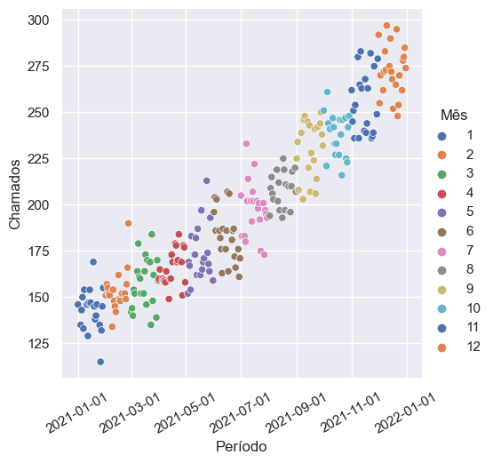

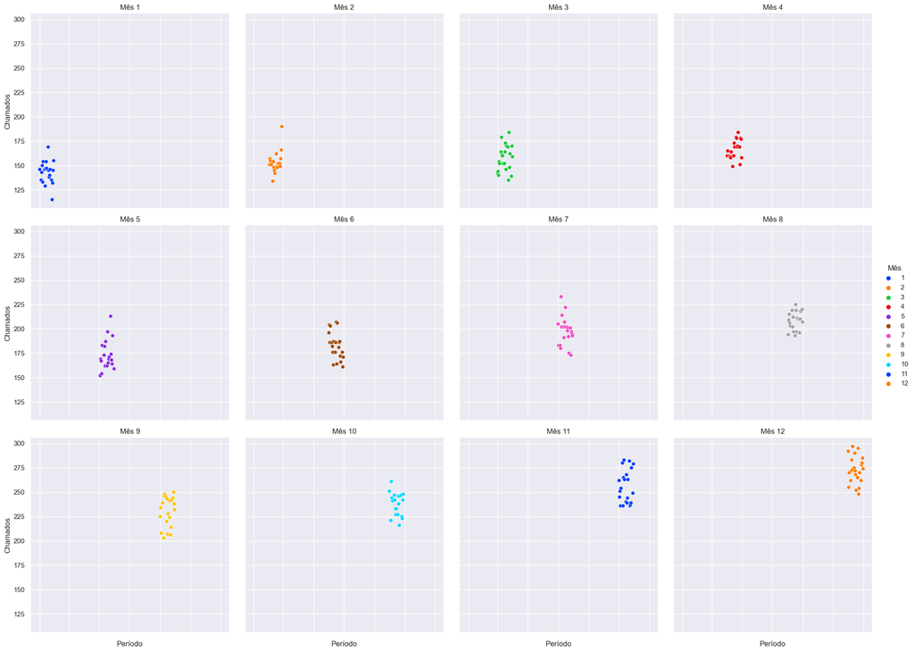

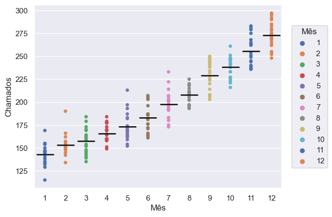

Há uma tendência de crescimento do número de ligações recebidas por dia ao longo do ano

### Análise e descrição dos tempos de serviço e de espera

#### Boxplot tempo de espera

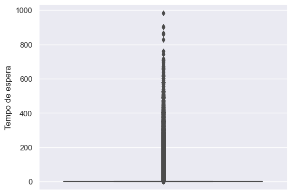

Há muitos outliers pois mais de 75% dos valores de tempo de espera são nulos, é melhor, portanto, não retirá-los

#### Boxplot tempo de serviço

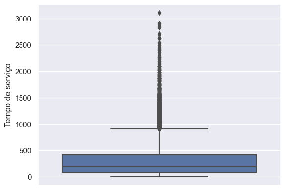

Há também alguns outliers na análise do tempo de serviço que não julgamos necessário retirar, pois é interessante modelar essa variável aleatória com uma distribuição que leve em consideração a presença de valores extremos

#### Scatter plots separados por mês

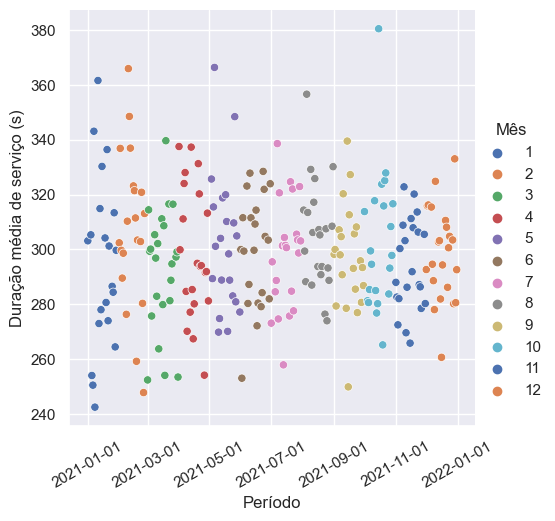

#### Strip plot das ligações

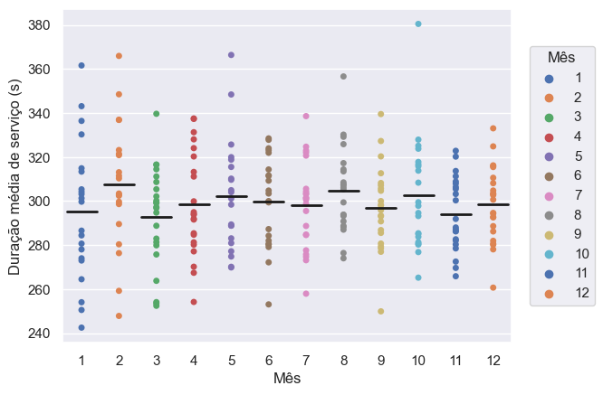

O tempo de serviço é aparentemente constante ao longo do ano, variando entre 4 e 6 minutos por ligação

Para testar nossas hipóteses utilizaremos o teste de Kolmogorov-Smirnov com 2 amostras. Esse teste é não paramétrico, isto é, não depende da distribuição das variáveis analisadas e testa a hipótese de que as duas amostras seguem uma mesma distribuição da seguinte forma:

$H_0:$ Ambas as amostras seguem uma mesma distribuição de probabilidade

$H_a:$ As amostras não seguem uma mesma distribuição de probabilidade

Portanto, definimos um nível de significância $\alpha = 0,05$ e analisamos os valores $p$ obtidos

p-values do teste de Kolmogorov-Smirnov para tempo de serviço entre meses

|  | Janeiro | Fevereiro | Março | Abril | Maio | Junho | Julho | Agosto | Setembro | Outubro | Novembro | Dezembro |
| --- | --- | --- | --- | --- | --- | --- | --- | --- | --- | --- | --- | --- |
| Janeiro | 1.000000 | 0.539682 | 0.812293 | 0.256586 | 0.686531 | 0.213343 | 0.901055 | 0.501365 | 0.646593 | 0.455533 | 0.851607 | 0.244136 |
| Fevereiro | 0.539682 | 1.000000 | 0.166747 | 0.567613 | 0.521534 | 0.597656 | 0.501749 | 0.712118 | 0.626175 | 0.414783 | 0.134640 | 0.781156 |
| Março | 0.812293 | 0.166747 | 1.000000 | 0.556098 | 0.532970 | 0.227363 | 0.807715 | 0.514176 | 0.637592 | 0.571722 | 0.999157 | 0.438829 |
| Abril | 0.256586 | 0.567613 | 0.556098 | 1.000000 | 0.285730 | 0.607213 | 0.124089 | 0.972075 | 0.619759 | 0.352190 | 0.585494 | 0.898245 |
| Maio | 0.686531 | 0.521534 | 0.532970 | 0.285730 | 1.000000 | 0.964981 | 0.942911 | 0.610175 | 0.645276 | 0.899609 | 0.474400 | 0.518063 |
| Junho | 0.213343 | 0.597656 | 0.227363 | 0.607213 | 0.964981 | 1.000000 | 0.609780 | 0.862771 | 0.907490 | 0.578312 | 0.256022 | 0.947341 |
| Julho | 0.901055 | 0.501749 | 0.807715 | 0.124089 | 0.942911 | 0.609780 | 1.000000 | 0.515389 | 0.954315 | 0.660659 | 0.748578 | 0.587768 |
| Agosto | 0.501365 | 0.712118 | 0.514176 | 0.972075 | 0.610175 | 0.862771 | 0.515389 | 1.000000 | 0.849642 | 0.875283 | 0.379730 | 0.900799 |
| Setembro | 0.646593 | 0.626175 | 0.637592 | 0.619759 | 0.645276 | 0.907490 | 0.954315 | 0.849642 | 1.000000 | 0.735153 | 0.539403 | 0.691972 |
| Outubro | 0.455533 | 0.414783 | 0.571722 | 0.352190 | 0.899609 | 0.578312 | 0.660659 | 0.875283 | 0.735153 | 1.000000 | 0.456450 | 0.889161 |
| Novembro | 0.851607 | 0.134640 | 0.999157 | 0.585494 | 0.474400 | 0.256022 | 0.748578 | 0.379730 | 0.539403 | 0.456450 | 1.000000 | 0.352761 |
| Dezembro | 0.244136 | 0.781156 | 0.438829 | 0.898245 | 0.518063 | 0.947341 | 0.587768 | 0.900799 | 0.691972 | 0.889161 | 0.352761 | 1.000000 |

O teste não paramétrico de Kolmogorov-Smirnov confirma que não há diferenças estatísticas significativas ($\alpha=0,05$) entre tempos de serviço ao longo do ano, avaliando em base mensal

#### Scatter plots tempos de espera separados por mês

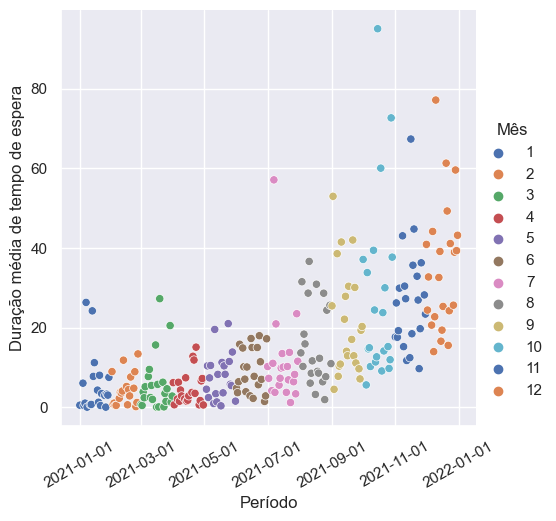

p-values do teste de Kolmogorov-Smirnov para tempo de espera entre meses

|  | Janeiro | Fevereiro | Março | Abril | Maio | Junho | Julho | Agosto | Setembro | Outubro | Novembro | Dezembro |
| --- | --- | --- | --- | --- | --- | --- | --- | --- | --- | --- | --- | --- |
| Janeiro | 1.000000 | 0.999994 | 0.987253 | 0.874800 | 0.068770 | 0.006124 | 0.000001 | 0.000000 | 0.000000 | 0.000000 | 0.000000 | 0.000000 |
| Fevereiro | 0.999994 | 1.000000 | 1.000000 | 0.999986 | 0.251817 | 0.039507 | 0.000020 | 0.000000 | 0.000000 | 0.000000 | 0.000000 | 0.000000 |
| Março | 0.987253 | 1.000000 | 1.000000 | 1.000000 | 0.336895 | 0.064457 | 0.000031 | 0.000000 | 0.000000 | 0.000000 | 0.000000 | 0.000000 |
| Abril | 0.874800 | 0.999986 | 1.000000 | 1.000000 | 0.569863 | 0.134464 | 0.000120 | 0.000000 | 0.000000 | 0.000000 | 0.000000 | 0.000000 |
| Maio | 0.068770 | 0.251817 | 0.336895 | 0.569863 | 1.000000 | 0.997352 | 0.034338 | 0.000006 | 0.000000 | 0.000000 | 0.000000 | 0.000000 |
| Junho | 0.006124 | 0.039507 | 0.064457 | 0.134464 | 0.997352 | 1.000000 | 0.204852 | 0.000097 | 0.000000 | 0.000000 | 0.000000 | 0.000000 |
| Julho | 0.000001 | 0.000020 | 0.000031 | 0.000120 | 0.034338 | 0.204852 | 1.000000 | 0.117362 | 0.000018 | 0.000000 | 0.000000 | 0.000000 |
| Agosto | 0.000000 | 0.000000 | 0.000000 | 0.000000 | 0.000006 | 0.000097 | 0.117362 | 1.000000 | 0.079798 | 0.000014 | 0.000000 | 0.000000 |
| Setembro | 0.000000 | 0.000000 | 0.000000 | 0.000000 | 0.000000 | 0.000000 | 0.000018 | 0.079798 | 1.000000 | 0.072091 | 0.000001 | 0.000000 |
| Outubro | 0.000000 | 0.000000 | 0.000000 | 0.000000 | 0.000000 | 0.000000 | 0.000000 | 0.000014 | 0.072091 | 1.000000 | 0.031059 | 0.000000 |
| Novembro | 0.000000 | 0.000000 | 0.000000 | 0.000000 | 0.000000 | 0.000000 | 0.000000 | 0.000000 | 0.000001 | 0.031059 | 1.000000 | 0.000054 |
| Dezembro | 0.000000 | 0.000000 | 0.000000 | 0.000000 | 0.000000 | 0.000000 | 0.000000 | 0.000000 | 0.000000 | 0.000000 | 0.000054 | 1.000000 |

O teste mostra que os tempos de espera até abril seguem uma mesma distribuição, mas a partir de maio, vemos que o p-value de 0.069 já indica maiores diferenças entre os tempos de espera dos meses de janeiro e maio

### Fit dos tempos de serviço

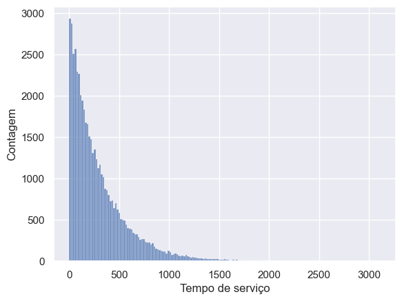

O histograma com os valores de tempos de serviço apresenta comportamento similar ao de uma distribuição exponencial

A distribuição exponencial é a candidata mais adequada para modelar o tempo de serviço

|  | sumsquare_error | aic | bic | kl_div | ks_statistic | ks_pvalue |
| --- | --- | --- | --- | --- | --- | --- |
| expon | 3.229e-08 | 2183.934 | -1.453e+06 | inf | 0.003 | 0.773 |

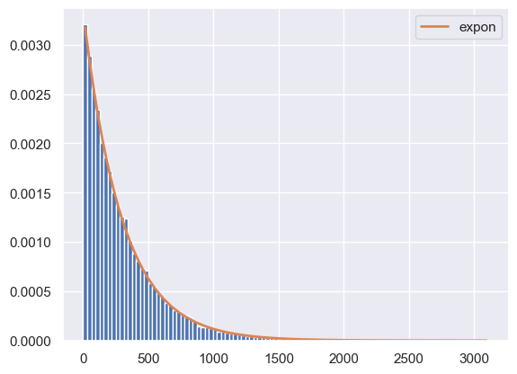

O tempo de serviço pode ser modelado por uma exponencial de média $299.10$

### Análise dos tempos entre chegadas das ligações

Avaliaremos o tempo de chegada a partir da diferença entre a chegada das chamadas em um dia

|  | call_id | date | daily_caller | call_started | call_answered | call_ended | wait_length | service_length | meets_standard | call_type | arrival_time_diff |
| --- | --- | --- | --- | --- | --- | --- | --- | --- | --- | --- | --- |
| 0 | 1 | 2021-01-01 | 1 | 1900-01-01 08:00:00 | 8:00:00 AM | 8:14:22 AM | 0 | 863 | True | 1 | 0.0 |
| 1 | 2 | 2021-01-01 | 2 | 1900-01-01 08:02:42 | 8:02:42 AM | 8:07:31 AM | 0 | 289 | True | 0 | 162.0 |
| 2 | 3 | 2021-01-01 | 3 | 1900-01-01 08:08:24 | 8:08:24 AM | 8:10:13 AM | 0 | 108 | True | 1 | 342.0 |
| 3 | 4 | 2021-01-01 | 4 | 1900-01-01 08:09:37 | 8:09:37 AM | 8:13:45 AM | 0 | 247 | True | 1 | 73.0 |
| 4 | 5 | 2021-01-01 | 5 | 1900-01-01 08:11:10 | 8:11:10 AM | 8:15:28 AM | 0 | 258 | True | 1 | 93.0 |

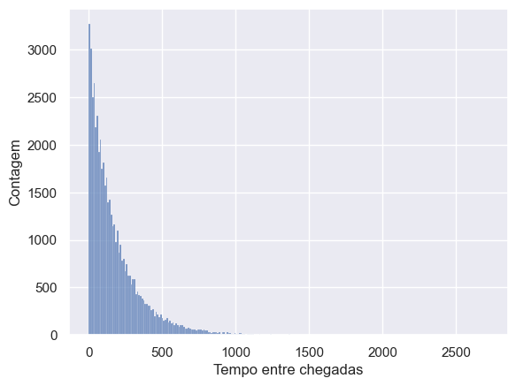

#### Scatter plots tempos entre chegadas separados por mês

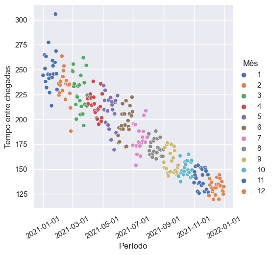

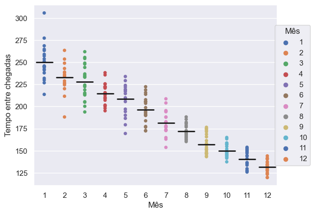

Há uma tendência de queda do tempo médio entre as chegadas ao longo do ano, isso está de acordo com a constatação de que o número de chamadas recebidas aumenta ao longo do ano

p-values do teste de Kolmogorov-Smirnov para intervalo de chegadas em base mensal

|  | Janeiro | Fevereiro | Março | Abril | Maio | Junho | Julho | Agosto | Setembro | Outubro | Novembro | Dezembro |
| --- | --- | --- | --- | --- | --- | --- | --- | --- | --- | --- | --- | --- |
| Janeiro | 1.000000 | 0.044309 | 0.001751 | 0.000000 | 0.000000 | 0.000000 | 0.000000 | 0.000000 | 0.000000 | 0.000000 | 0.000000 | 0.000000 |
| Fevereiro | 0.044309 | 1.000000 | 0.050702 | 0.016655 | 0.000006 | 0.000000 | 0.000000 | 0.000000 | 0.000000 | 0.000000 | 0.000000 | 0.000000 |
| Março | 0.001751 | 0.050702 | 1.000000 | 0.143584 | 0.005403 | 0.000011 | 0.000000 | 0.000000 | 0.000000 | 0.000000 | 0.000000 | 0.000000 |
| Abril | 0.000000 | 0.016655 | 0.143584 | 1.000000 | 0.063691 | 0.002019 | 0.000000 | 0.000000 | 0.000000 | 0.000000 | 0.000000 | 0.000000 |
| Maio | 0.000000 | 0.000006 | 0.005403 | 0.063691 | 1.000000 | 0.031724 | 0.000034 | 0.000000 | 0.000000 | 0.000000 | 0.000000 | 0.000000 |
| Junho | 0.000000 | 0.000000 | 0.000011 | 0.002019 | 0.031724 | 1.000000 | 0.003164 | 0.000012 | 0.000000 | 0.000000 | 0.000000 | 0.000000 |
| Julho | 0.000000 | 0.000000 | 0.000000 | 0.000000 | 0.000034 | 0.003164 | 1.000000 | 0.238733 | 0.000005 | 0.000000 | 0.000000 | 0.000000 |
| Agosto | 0.000000 | 0.000000 | 0.000000 | 0.000000 | 0.000000 | 0.000012 | 0.238733 | 1.000000 | 0.004325 | 0.000000 | 0.000000 | 0.000000 |
| Setembro | 0.000000 | 0.000000 | 0.000000 | 0.000000 | 0.000000 | 0.000000 | 0.000005 | 0.004325 | 1.000000 | 0.016511 | 0.000001 | 0.000000 |
| Outubro | 0.000000 | 0.000000 | 0.000000 | 0.000000 | 0.000000 | 0.000000 | 0.000000 | 0.000000 | 0.016511 | 1.000000 | 0.011048 | 0.000011 |
| Novembro | 0.000000 | 0.000000 | 0.000000 | 0.000000 | 0.000000 | 0.000000 | 0.000000 | 0.000000 | 0.000001 | 0.011048 | 1.000000 | 0.000021 |
| Dezembro | 0.000000 | 0.000000 | 0.000000 | 0.000000 | 0.000000 | 0.000000 | 0.000000 | 0.000000 | 0.000000 | 0.000011 | 0.000021 | 1.000000 |

|  | sumsquare_error | aic | bic | kl_div | ks_statistic | ks_pvalue |
| --- | --- | --- | --- | --- | --- | --- |
| expon | 1.819e-07 | 2555.015 | -1.364e+06 | inf | 0.013 | 3.530e-08 |

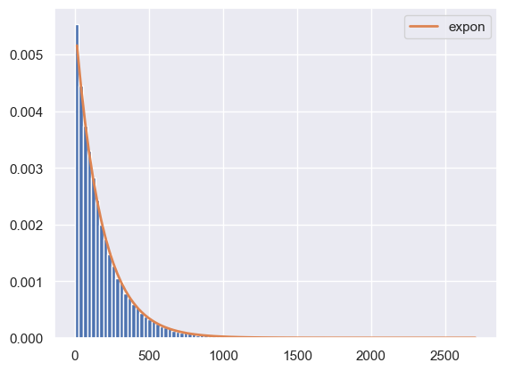

O fit para o ano todo não modela tão bem o problema, visto que os tempos de chegada das chamadas variam ao longo do ano, e tais distribuições avaliadas não levam em conta o parâmetro do tempo

### Teste de correlação entre os tempos estudados utilizando a correlação de Spearman

|  | wait_length | service_length | arrival_time_diff |
| --- | --- | --- | --- |
| wait_length | 1.000 | 3.741e-03 | -2.622e-01 |
| service_length | 0.004 | 1.000e+00 | -5.214e-04 |
| arrival_time_diff | -0.262 | -5.214e-04 | 1.000e+00 |

p-values do teste de correlação de Spearman para as variáveis aleatórias estudadas

|  | wait_length | service_length | arrival_time_diff |
| --- | --- | --- | --- |
| wait_length | 0.000000 | 0.394934 | 0.000000 |
| service_length | 0.394934 | 0.000000 | 0.905620 |
| arrival_time_diff | 0.000000 | 0.905620 | 0.000000 |

Portanto, temos correlação entre wait_length e arrival_time_diff, confirmando a hipótese que o tempo de espera depende do intervalo entre chegadas

### Análise por call types

É interessante analisar o comportamento de nossas variáveis aleatórias com relação ao tipo de ligação realizada. Há alguma diferença significativa entre os tipos 0, 1 e 2?

```
Ligações do tipo 0 atendidas em 2021: 12830
Ligações que demoraram mais de 60 segundos para atendimento: 1069
No ano de 2021, em média, 8.33% das ligações do tipo 0 demoraram mais de 60 segundos para serem atendidas
```

```
Ligações do tipo 1 atendidas em 2021: 25792
Ligações que demoraram mais de 60 segundos para atendimento: 2100
No ano de 2021, em média, 8.14% das ligações do tipo 1 demoraram mais de 60 segundos para serem atendidas
```

```
Ligações do tipo 2 atendidas em 2021: 13086
Ligações que demoraram mais de 60 segundos para atendimento: 1058
No ano de 2021, em média, 8.08% das ligações do tipo 2 demoraram mais de 60 segundos para serem atendidas
```

#### Teste não paramétrico para testar se os tempos de interesse são iguais para todos os tipos de ligação

p-values do teste de Kolmogorov-Smirnov para duração de serviço

|  | Call_type 0 | Call_type 1 | Call_type 2 |
| --- | --- | --- | --- |
| Call_type 0 | 1.000000 | 0.624788 | 0.441323 |
| Call_type 1 | 0.624788 | 1.000000 | 0.771999 |
| Call_type 2 | 0.441323 | 0.771999 | 1.000000 |

p-values do teste de Kolmogorov-Smirnov para intervalos de chegadas

|  | Call_type 0 | Call_type 1 | Call_type 2 |
| --- | --- | --- | --- |
| Call_type 0 | 1.000000 | 0.985760 | 0.999016 |
| Call_type 1 | 0.985760 | 1.000000 | 0.994172 |
| Call_type 2 | 0.999016 | 0.994172 | 1.000000 |

p-values do teste de Kolmogorov-Smirnov para tempos de espera

|  | Call_type 0 | Call_type 1 | Call_type 2 |
| --- | --- | --- | --- |
| Call_type 0 | 1.000000 | 0.968333 | 0.999602 |
| Call_type 1 | 0.968333 | 1.000000 | 1.000000 |
| Call_type 2 | 0.999602 | 1.000000 | 1.000000 |

Não há diferença estatística entre as distribuições dos tempos de chegada, de serviço e de espera de acordo com o tipo de ligação em base anual

## Análise mensal

Tabela de resumo das médias dos tempos de espera, serviço e de chegada de ligações mês a mês

|  | mes | mean_wait_length | mean_service_length | mean_arrival_time_diff | mean_daily_calls | %_failure |
| --- | --- | --- | --- | --- | --- | --- |
| 0 | Janeiro | 5.375000 | 295.091333 | 248.624000 | 143.047619 | 2.533333 |
| 1 | Fevereiro | 4.363280 | 307.153545 | 231.885332 | 153.300000 | 2.482849 |
| 2 | Março | 5.659839 | 293.362026 | 226.209798 | 157.347826 | 2.767783 |
| 3 | Abril | 4.787479 | 298.619989 | 214.172433 | 165.863636 | 2.828116 |
| 4 | Maio | 7.984802 | 301.791379 | 206.973750 | 173.190476 | 4.227687 |
| 5 | Junho | 9.218843 | 299.669242 | 195.431206 | 182.818182 | 4.985045 |
| 6 | Julho | 11.794931 | 298.707143 | 180.276498 | 197.772727 | 6.036866 |
| 7 | Agosto | 16.159325 | 304.865878 | 171.872452 | 208.090909 | 7.911462 |
| 8 | Setembro | 21.536639 | 296.592991 | 156.499403 | 229.090909 | 10.115492 |
| 9 | Outubro | 27.894146 | 302.287891 | 149.751203 | 238.047619 | 11.768244 |
| 10 | Novembro | 27.372567 | 294.149491 | 139.963744 | 255.727273 | 13.698875 |
| 11 | Dezembro | 35.544247 | 298.742519 | 131.373340 | 272.695652 | 16.546647 |

Portanto, o percentual falhas, aqui definido como o percentual de chamadas que demoram mais de 60 segundos para serem atendidas, aumenta mês a mês, ultrapassando, a partir de setembro de 2021, a tolerância de 10% estipulada pelo gerente

## Análise trimestral

|  | periodo | mean_wait_length | mean_service_length | mean_arrival_time_diff | mean_daily_calls | %_failure |
| --- | --- | --- | --- | --- | --- | --- |
| 0 | Trimestre 1 | 5.161257 | 298.262146 | 234.956481 | 151.390625 | 2.604920 |
| 1 | Trimestre 2 | 7.391023 | 300.011532 | 205.191520 | 173.969231 | 4.045063 |
| 2 | Trimestre 3 | 16.738384 | 299.962801 | 168.947504 | 211.651515 | 8.122083 |
| 3 | Trimestre 4 | 30.560169 | 298.265443 | 139.674982 | 256.015152 | 14.183892 |

Uma agregação maior do que um mês, como a trimestral, subestima a porcentagem de falhas e pode esconder informações como a falha no mês de setembro, que está no 3º trimestre. Além disso, vimos que não é correto agregar o intervalo de chegadas em períodos maiores que um mês, já que este valor é alterado mensalmente

## Análise semanal

Testes de hipótese para verificar se há diferenças estatisticamente significativas do intervalo de chegada semana a semana

|  | 1 | 2 | 3 | 4 | 5 | 6 | 7 | 8 |
| --- | --- | --- | --- | --- | --- | --- | --- | --- |
| 1 | 1.000000 | 0.895541 | 0.635506 | 0.615615 | 0.497819 | 0.966903 | 0.588041 | 0.093597 |
| 2 | 0.895541 | 1.000000 | 0.823594 | 0.607070 | 0.351146 | 0.985249 | 0.443794 | 0.121901 |
| 3 | 0.635506 | 0.823594 | 1.000000 | 0.312581 | 0.381446 | 0.651136 | 0.470177 | 0.241507 |
| 4 | 0.615615 | 0.607070 | 0.312581 | 1.000000 | 0.057124 | 0.717159 | 0.115002 | 0.033184 |
| 5 | 0.497819 | 0.351146 | 0.381446 | 0.057124 | 1.000000 | 0.167075 | 0.958201 | 0.147202 |
| 6 | 0.966903 | 0.985249 | 0.651136 | 0.717159 | 0.167075 | 1.000000 | 0.548558 | 0.056267 |
| 7 | 0.588041 | 0.443794 | 0.470177 | 0.115002 | 0.958201 | 0.548558 | 1.000000 | 0.161125 |
| 8 | 0.093597 | 0.121901 | 0.241507 | 0.033184 | 0.147202 | 0.056267 | 0.161125 | 1.000000 |

|  | 45 | 46 | 47 | 48 | 49 | 50 | 51 | 52 |
| --- | --- | --- | --- | --- | --- | --- | --- | --- |
| 45 | 1.000000 | 0.182244 | 0.857725 | 0.320285 | 0.071961 | 0.166746 | 0.320232 | 0.180710 |
| 46 | 0.182244 | 1.000000 | 0.602844 | 0.125497 | 0.024914 | 0.181061 | 0.093705 | 0.080147 |
| 47 | 0.857725 | 0.602844 | 1.000000 | 0.139887 | 0.032820 | 0.140556 | 0.142464 | 0.104228 |
| 48 | 0.320285 | 0.125497 | 0.139887 | 1.000000 | 0.693380 | 0.949007 | 0.956980 | 0.933944 |
| 49 | 0.071961 | 0.024914 | 0.032820 | 0.693380 | 1.000000 | 0.696904 | 0.776036 | 0.735916 |
| 50 | 0.166746 | 0.181061 | 0.140556 | 0.949007 | 0.696904 | 1.000000 | 0.920658 | 0.793146 |
| 51 | 0.320232 | 0.093705 | 0.142464 | 0.956980 | 0.776036 | 0.920658 | 1.000000 | 0.661372 |
| 52 | 0.180710 | 0.080147 | 0.104228 | 0.933944 | 0.735916 | 0.793146 | 0.661372 | 1.000000 |

No horizonte de planejamento semanal, semanas subsequentes tendem a ter intervalos de chegada que seguem a mesma distribuição de probabilidade, e, portanto, o planejamento semanal não é interessante para esse problema, visto que não é possível perceber as diferenças de demanda nesse nível de análise

## Processo de modelagem dos intervalos entre chegadas (Regressão Linear e Expo)

### Regressão linear diária dos tempos entre chegadas

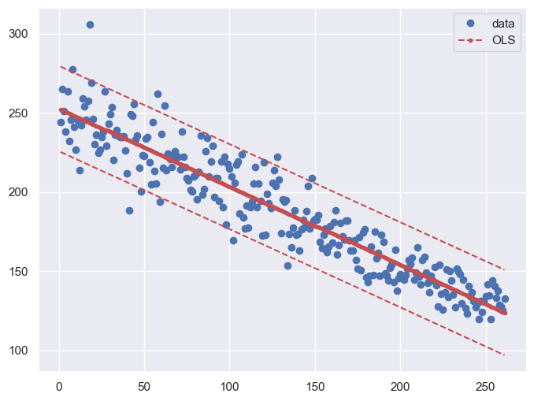

[figure not shown]

Temos que os valores p são menores que o nível de significância adotado, e, portanto, o modelo de regressão existe. O intervalo entre chegadas depende do dia trabalhado seguindo a expressão: $$intervalos(t) = -0,4933 \cdot t + 252,6629$$ Em que $t$ é um dia útil trabalhado.

Entretanto, para os dias em que $t > 512$ o tempo de chegada das chamadas seria negativo, o que levanta questões sobre se este método de regressão é aplicável para modelar o tempo entre as chamadas.

### Regressão exponencial diária dos tempos entre chegadas

[figure not shown]

Para Este caso, a explicabilidade do modelo aumentou e o problema de obter intervalos negativos de tempo é solucionado. Como os valores $p$ seguem menores do que 0, o modelo existe e pode ser usado.

No Modelo de regressão exponencial, temos: $$intervalos(t) = 260,9424 \cdot e^{-0,0027t} $$

obs: $260,9424 = e^{5,5643}$

### Regressão exponencial dos tempos entre chegadas em base mensal

[output not shown]

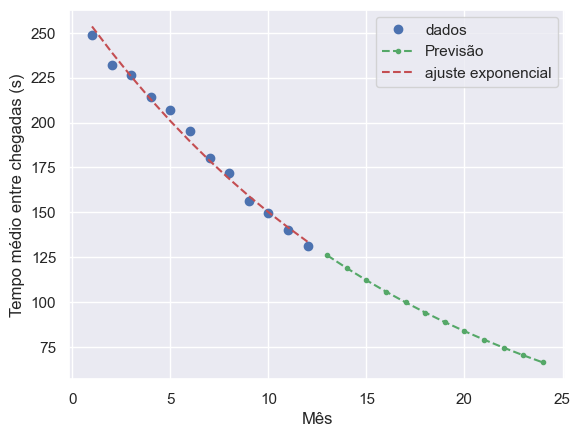

[figure not shown]

### Regressão exponencial do número de ligações em base mensal

[output not shown]

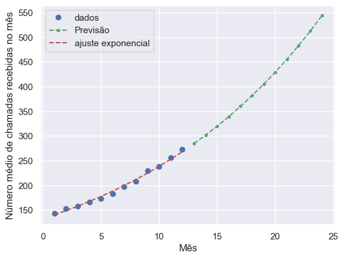

# Arena

## Modelo

[figure not shown]

## Validação do modelo de simulação simplificado

É feita a análise para cada mês com 100 replicações

### Validação do modelo de simulação mês a mês

|  | wait_length | service_length | arrival_time_diff |
| --- | --- | --- | --- |
| Janeiro | 1.000000 | 0.317516 | 0.310957 |
| Fevereiro | 1.000000 | 0.313462 | 0.056111 |
| Março | 0.999991 | 0.594809 | 0.685034 |
| Abril | 0.884678 | 0.172664 | 0.060925 |
| Maio | 1.000000 | 0.560986 | 0.308715 |
| Junho | 1.000000 | 0.493718 | 0.713599 |
| Julho | 1.000000 | 0.778257 | 0.579550 |
| Agosto | 0.802289 | 0.697168 | 0.547951 |
| Setembro | 0.970986 | 0.867880 | 0.570443 |
| Outubro | 0.996798 | 0.285392 | 0.897156 |
| Novembro | 0.148013 | 0.740257 | 0.084251 |
| Dezembro | 0.071930 | 0.628589 | 0.267467 |

## Modelo de simulação com tempo entre chegadas variando conforme regressão exponencial diária (todo o ano de 2021)

### Validação do modelo de simulação mês a mês

|  | wait_length | service_length | arrival_time_diff |
| --- | --- | --- | --- |
| Janeiro | 1.000000 | 0.687544 | 0.970258 |
| Fevereiro | 0.973854 | 0.514778 | 0.482204 |
| Março | 1.000000 | 0.161404 | 0.455566 |
| Abril | 0.663732 | 0.118587 | 0.048333 |
| Maio | 0.757560 | 0.537213 | 0.414667 |
| Junho | 0.025933 | 0.678915 | 0.173306 |
| Julho | 1.000000 | 0.553623 | 0.594623 |
| Agosto | 0.992315 | 0.433233 | 0.171680 |
| Setembro | 0.565452 | 0.832067 | 0.884495 |
| Outubro | 0.054283 | 0.065737 | 0.655950 |
| Novembro | 0.850449 | 0.346603 | 0.047764 |
| Dezembro | 0.172692 | 0.552536 | 0.047296 |

## Modelo com tempo entre chegadas definidos com operadores lógicos

[figure not shown]

### Validação do modelo de simulação mês a mês

|  | wait_length | service_length | arrival_time_diff |
| --- | --- | --- | --- |
| Janeiro | 1.000000 | 0.599962 | 0.633926 |
| Fevereiro | 0.999991 | 0.449836 | 0.069227 |
| Março | 1.000000 | 0.136573 | 0.581367 |
| Abril | 0.722717 | 0.135395 | 0.059532 |
| Maio | 0.863854 | 0.612953 | 0.881812 |
| Junho | 0.218641 | 0.507515 | 0.885655 |
| Julho | 1.000000 | 0.639461 | 0.791167 |
| Agosto | 0.999977 | 0.579174 | 0.291595 |
| Setembro | 0.273815 | 0.648022 | 0.578689 |
| Outubro | 0.050895 | 0.065970 | 0.643047 |
| Novembro | 0.711927 | 0.722038 | 0.074237 |
| Dezembro | 0.229570 | 0.620860 | 0.132849 |

## Capacidade de atendimento atual

[figure not shown]

Tomando $100$ amostras, com $95\%$ de confiança, temos o seguinte intervalo em torno da média: $226,52 \leq \mu \leq 232,66$

# Soluções propostas

## 1. Contratação de atendentes

- Planos de contratação;
- Cenário com cumprimento total da meta;
- Cenário alternativo (econômico).

## Estratégia de contratação preventiva

[figure not shown]

## Estratégia de contratação econômica

[figure not shown]

## 2. Subcontratação

- Terceirizar parte do atendimento;
- Alternativa à contratação de novos funcionários;
- Dependente do tipo de serviço oferecido pela empresa;
- Pode ser mais econonomicamente interessante.

## 3. Redução do tempo de atendimento

- Mapeamento de processos;
- Enfoque em aumentar a eficiência dos atendimentos;
- Investir em treinamentos dos atendentes;
- Resolver os atendimentos de forma mais rápida.

## 5. Classificação efetiva dos tipos de ligação recebidas

- Os tipos de ligação cadastrados pela central não contribuiram para a análise;
- Estudo posterior para filtrar efetivamente os tipos de ligação recebidos;
- Possibilidade de classificar tipos de ligação por complexidade para realizar triagem dos atendimentos por chatbot.

## 6. Melhoria na comunicação com os clientes

- Manter os clientes informados quanto aos status de atendimentos, reduzindo desistências;
- Orientar o cliente a preparar as informações relevantes para o atendimento no período de espera.

# Obrigado!

[figure not shown]